# Praca Domowa 2

Piotr Kotlowski

2024-10-29

## Dane

Dane wykorzystane w Pracy domowej 2 opisują wycenę nieruchmości. Każda obserwacja jest pewną nieruchmością, która posiada informacje takie jak powierzchnia, liczba pokoi, liczba łazienek i wiele więcj. Opis wszystkich kolumn w pliku `README.md`.

## Zadanie 1

Jak wygląda rozkład ceny nieruchomości w poszczególnych kodach pocztowych na przestrzeni lat? Rozważamy kody pocztowe, które mają więcej niż 280 posiadłości.

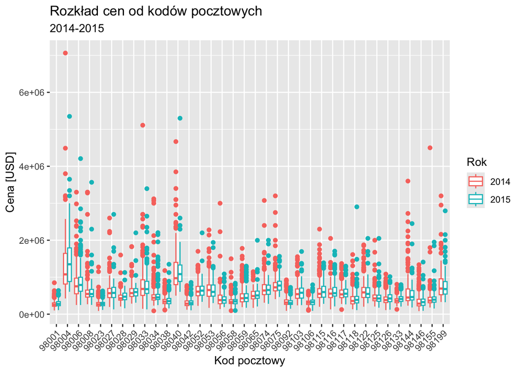

```r
zad1<-df%>%
  group_by(zipcode)%>%
  mutate(count=n_distinct(id))%>%
  filter(count>280)


zad1$date <- as.Date(zad1$date, format="%Y%m%dT%H%M%S")
zad1$year <- format(zad1$date, "%Y")


ggplot(data=zad1, aes(x = as.factor(zipcode), y = price, color = as.factor(year))) +
  geom_boxplot() +
  scale_x_discrete(guide=guide_axis(angle=45))+
  labs(title = "Rozkład cen od kodów pocztowych",
       subtitle="2014-2015",
       x = "Kod pocztowy", y = "Cena [USD]",color="Rok")
```

## Zadanie 2

Czy jest różnica w rozkładzie ceny nierchomości od powierzchni mieszkalnej uwzględniając podział na nieruchomości z piwnicą i bez?

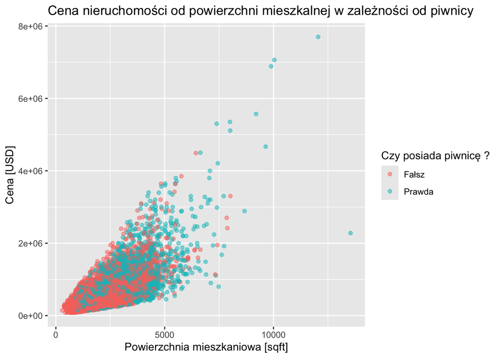

```r
# Tu umieść kod do wygenerowania odpowiedzi do zadania.

zad2<-df%>%
  mutate(BasementBool=case_when(sqft_basement==0~"Fałsz",
                                TRUE~'Prawda'))%>%
  select(id,price,sqft_living,BasementBool)

ggplot(data=zad2,aes(y=price,x=sqft_living,color=as.factor(BasementBool)))+
  geom_point(alpha=0.5)+
  labs(title = "Cena nieruchomości od powierzchni mieszkalnej w zależności od piwnicy",
       x = "Powierzchnia mieszkaniowa [sqft]", y = "Cena [USD]",color="Czy posiada piwnicę ?")
```

**Komentarz:Mieszkania nie posiadające piwnic są zazwyczaj tańsze oraz mają mniejszą powierzchnię.**

## Zadanie 3

Jaka jest zależność pomiędzy jakością wykończenia nieruchomości a liczbą pięter?

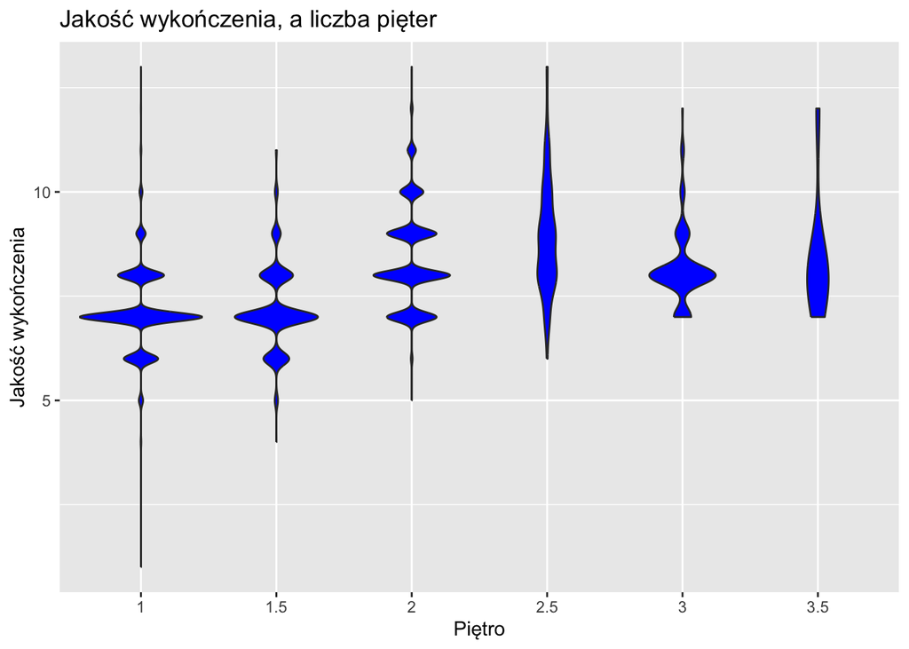

```r
# Tu umieść kod do wygenerowania odpowiedzi do zadania.
zad3<-df%>%
  group_by(floors,grade)%>%
  mutate(count=n())%>%
  select(floors,id,grade,count)

ggplot(data=zad3,aes(x=as.factor(floors),y=grade))+
  geom_violin(fill="blue")+
  labs(title = "Jakość wykończenia, a liczba pięter",
       x = "Piętro", y = "Jakość wykończenia")
```

**Komentarz: Mieszkanie mające więcej pięter zazwyczaj mają lepszą jakość wykończenia.**

## Zadanie 4 Jaka jest zależność między powierzchnią mieszkalną nieruchomości a powierzchnią gruntu w podziale na liczbę sypialni?

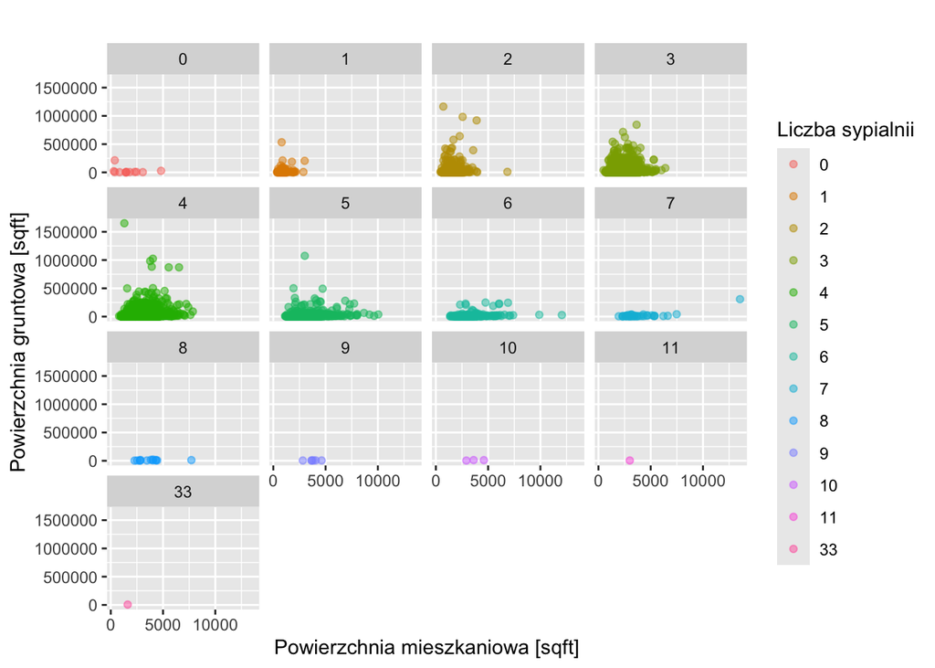

```r
# Tu umieść kod do wygenerowania odpowiedzi do zadania.
zad4<-df%>%
  select(id,sqft_living,sqft_lot,bedrooms)

ggplot(data=zad4,aes(x=sqft_living,y=sqft_lot,color,color=as.factor(bedrooms)))+
  geom_point(alpha=0.5)+
  facet_wrap(~as.factor(bedrooms))+
  labs(title="",x="Powierzchnia mieszkaniowa [sqft]",y="Powierzchnia gruntowa [sqft]",
       color='Liczba sypialnii')
```

**Komentarz: Mieszkania mające więcej sypialnii, mają większą powierzchnię mieszkaniową. Ciężko wskazać zależność powierzchnii mieszkaniowej od powierzchnii gruntowej.**

## Zadanie 5 Rozważmy tylko nieruchomości, które miały remont. W której dekadzie było najwięcej przeprowadzonych remontów? Czy w poszczególnych dekadach jest porównywalny procent nieruchmości dla każdej wartości miary jakości i wykończenia nieruchomości?

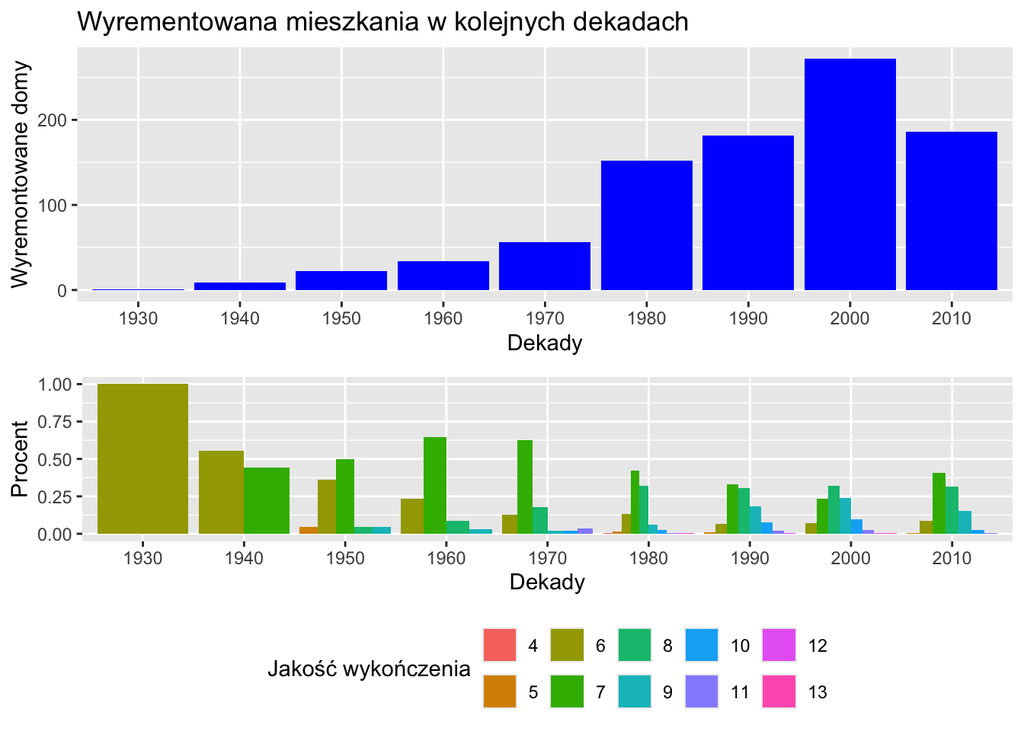

```r
# Tu umieść kod do wygenerowania odpowiedzi do zadania.
zad5<-df%>%
  mutate(IsRenovated=case_when(yr_renovated!=0~TRUE,
                               TRUE~FALSE),
         decadeRenovated=(yr_renovated%/%10)*10
  )%>%
  filter(IsRenovated==TRUE)%>%
  group_by(decadeRenovated)%>%
  mutate(NumberOfProperty=n())%>%
  group_by(decadeRenovated,grade)%>%
  mutate(CountGrade=n(),ProcGrade=CountGrade/NumberOfProperty)




p1<-ggplot(data=zad5,aes(x=as.factor(decadeRenovated)))+
  geom_bar(fill="blue")+
  labs(x="Dekady",y="Wyremontowane domy",title="Wyrementowana mieszkania w kolejnych dekadach")


p2<-ggplot(data=zad5,aes(x=as.factor(decadeRenovated),y=ProcGrade,fill=as.factor(grade)))+
  geom_col(position = "dodge") +
  labs(y="Procent",x="Dekady",fill="Jakość wykończenia")+
  theme(legend.position = "bottom")

grid.arrange(p1,p2)
```

**Komentarz:Najwięcej wyremontowanych domów było w 2000 dekadzie. Nie, w poszczególnych dekadach nie było porównywalnego procentu nieruchmości dla każdej wartości miary jakości i wykończenia nieruchomości.**

## Zadanie 6

Jak prezentuje się wartość minimalna, średnia i maksymalna ceny nieruchmości w podziele na rok budowy nieruchomości.

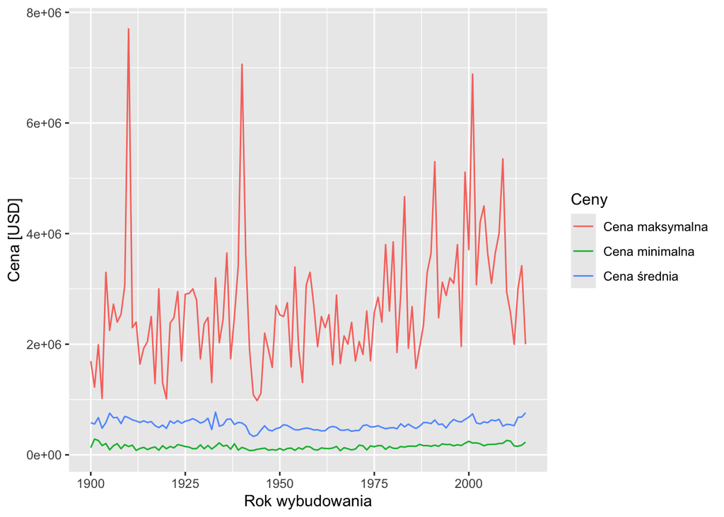

```r
# Tu umieść kod do wygenerowania odpowiedzi do zadania.
zad6<-df%>%
  group_by(yr_built)%>%
  summarise(maxPrice=max(price,na.rm=TRUE),
            minPrice=min(price,na.rm=TRUE),
            avgPrice=mean(price,na.rm=TRUE))


ggplot(data=zad6,aes(x=yr_built))+
  geom_line(aes(y = minPrice, color = 'Cena minimalna')) +
  geom_line(aes(y = avgPrice, color = 'Cena średnia')) +
  geom_line(aes(y = maxPrice, color = 'Cena maksymalna')) +
  labs(x="Rok wybudowania",y="Cena [USD]",color="Ceny")
```

**Komentarz:Na przestrzeni lat bardzo duże wahania maksymalnej ceny mieszkań. Cena minimanlna oraz średnia utrzymująca się na podobnym poziomie.**